# Psychosocial Dimensions of Student Life Report

Lindolfo Cavalcanti

2024/07

# Introduction

## Dataset Discription

So, with that in mind, these are the variables and their description according to the creators:

### Age:

Represents the age of the individuals in the dataset, providing insight into the age distribution of the study.

### Gender:

Indicates the gender of each individual, allowing for the exploration of gender-related patterns and trends within the dataset.

### Academic Performance:

Reflects the academic achievements of individuals.

### Taking Note In Class:

Describes about individuals take notes during class, providing insights into study habits and engagement during lectures.

### Depression Status:

Indicates the presence or absence of depressive symptoms, contributing valuable information about the mental health of individuals in the dataset.

### Face Challenges To Complete Academic Task:

Explores whether individuals encounter challenges in completing academic tasks.

### Like Presentation:

Reflects individuals’ preferences for presentations, offering insights into their learning style and engagement with visual or oral communication. This aim also measure is they extrovert or introvert.

### Sleep Per Day Hours:

Represents the average hours of sleep individuals get per day, providing information on sleep patterns and potential correlations with academic performance.

### Number Of Friend:

Quantifies the social aspect by indicating the number of friends each individual has, contributing to the understanding of social dynamics within the dataset.

### Like New Things:

Explores individuals’ receptiveness to new experiences or concepts, offering insights into their adaptability and openness to innovation.

## Objectives

The main objective in this report is to explore the data and try to find any link between the variables and the depression levels in these students.

Therefore, to accomplish this, a few basic steps are recommended. They are:

- Data Exploration
- Data Cleaning
- Data Analysis
  - Normalities Tests
  - Investigate Possible Correlations
  - Statistical Tests

Each stage of this investigation will be explained and discussed. Besides, the thinking process of the analysis will be exposed.

# Data Exploration

Variables Characteristics

| Index | Variable_Name | Class | Sample | NA Values | Percentage of NA | Distinct Values |
| --- | --- | --- | --- | --- | --- | --- |
| 1 | Age | numeric | 99 | 0 | 0.00 | 6 |
| 2 | Gender | factor | 99 | 0 | 0.00 | 2 |
| 3 | AcademicPerformance | factor | 99 | 0 | 0.00 | 4 |
| 4 | TakingNoteInClass | factor | 99 | 0 | 0.00 | 3 |
| 5 | DepressionStatus | factor | 99 | 0 | 0.00 | 3 |
| 6 | FaceChallangesToCompleteAcademicTask | factor | 99 | 0 | 0.00 | 3 |
| 7 | LikePresentation | factor | 99 | 0 | 0.00 | 2 |
| 8 | SleepPerDayHours | numeric | 99 | 0 | 0.00 | 7 |
| 9 | NumberOfFriend | numeric | 95 | 4 | 0.04 | 17 |
| 10 | LikeNewThings | factor | 99 | 0 | 0.00 | 2 |

Variables Diagnose

| Variables | Levels | Sample | Frequency | Ratio | Rank |
| --- | --- | --- | --- | --- | --- |
| Gender | Male | 99 | 56 | 56.565657 | 1 |
| Gender | Female | 99 | 43 | 43.434343 | 2 |
| AcademicPerformance | Average | 99 | 45 | 45.454545 | 1 |
| AcademicPerformance | Good | 99 | 41 | 41.414141 | 2 |
| AcademicPerformance | Excellent | 99 | 9 | 9.090909 | 3 |
| AcademicPerformance | Below average | 99 | 4 | 4.040404 | 4 |
| TakingNoteInClass | Yes | 99 | 61 | 61.616162 | 1 |
| TakingNoteInClass | Sometimes | 99 | 26 | 26.262626 | 2 |
| TakingNoteInClass | No | 99 | 12 | 12.121212 | 3 |
| DepressionStatus | Sometimes | 99 | 44 | 44.444444 | 1 |
| DepressionStatus | Yes | 99 | 34 | 34.343434 | 2 |
| DepressionStatus | No | 99 | 21 | 21.212121 | 3 |
| FaceChallangesToCompleteAcademicTask | Yes | 99 | 37 | 37.373737 | 1 |
| FaceChallangesToCompleteAcademicTask | No | 99 | 31 | 31.313131 | 2 |
| FaceChallangesToCompleteAcademicTask | Sometimes | 99 | 31 | 31.313131 | 2 |
| LikePresentation | Yes | 99 | 69 | 69.696970 | 1 |
| LikePresentation | No | 99 | 30 | 30.303030 | 2 |
| LikeNewThings | Yes | 99 | 89 | 89.898990 | 1 |
| LikeNewThings | No | 99 | 10 | 10.101010 | 2 |

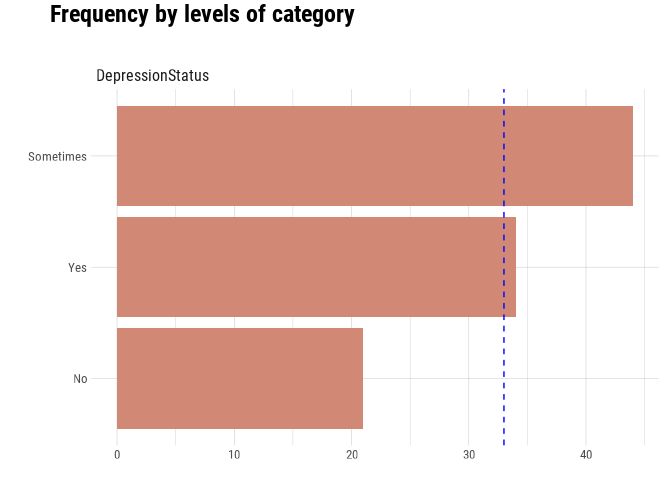

# Data Cleaning

## Removing Outliers

Outliers Diagnose

| Variables | N. Outliers | outliers_ratio | Outliers Mean | With Outliers Mean | Without Outliers Mean |
| --- | --- | --- | --- | --- | --- |
| Age | 0 | 0.00000 |  | 22.53684 | 22.536842 |
| SleepPerDayHours | 0 | 0.00000 |  | 6.60000 | 6.600000 |
| NumberOfFriend | 13 | 13.68421 | 75.76923 | 16.18947 | 6.743902 |

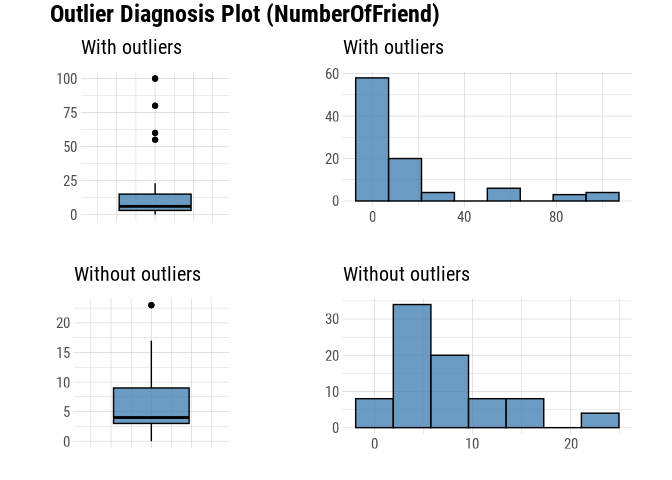

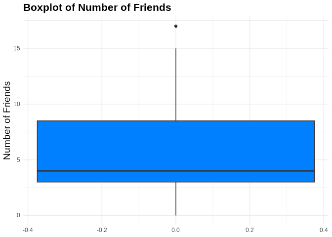

# Data Analysis

## Normality Tests

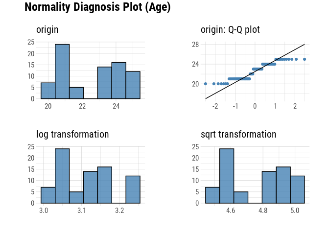

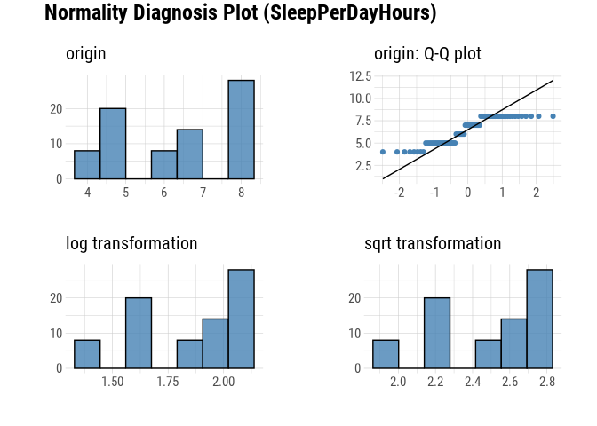

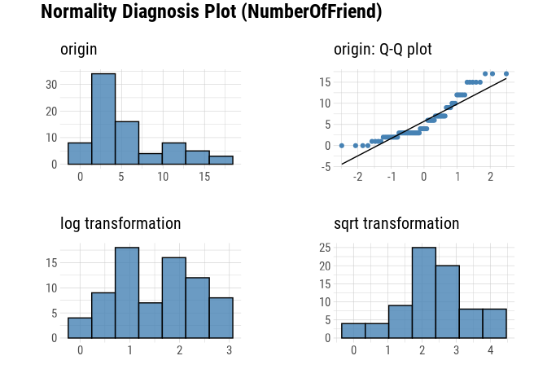

Normality Test to Numeric Variables

| Variables | Statistic | P value | Sample |
| --- | --- | --- | --- |
| Age | 0.8855428 | 0.00000400878685 | 78 |
| SleepPerDayHours | 0.8370633 | 0.00000008141697 | 78 |
| NumberOfFriend | 0.8826146 | 0.00000309218833 | 78 |

Shapiro-Wilk Test - Not normally distributed

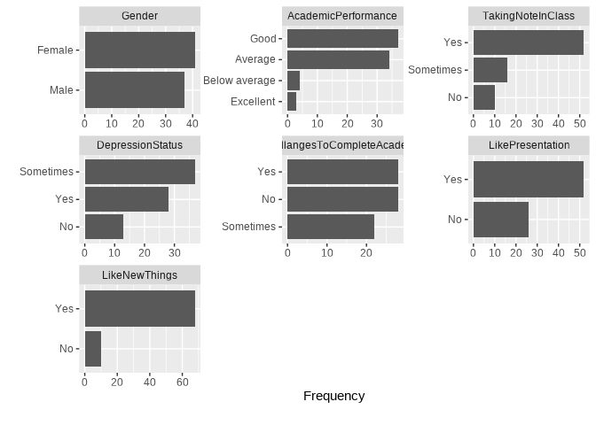

# Depression Status Correlations

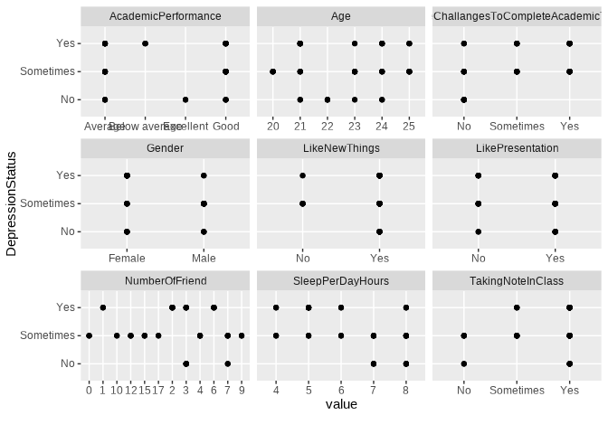

Comparation Between Gender and Depression Status

| Gender | Depression Status | Occurrences | Rate | Gender | Depression Status Rate |
| --- | --- | --- | --- | --- | --- |
| Female | No | 8 | 0.10256410 | 0.19512195 | 0.6153846 |
| Female | Sometimes | 8 | 0.10256410 | 0.19512195 | 0.2162162 |
| Female | Yes | 25 | 0.32051282 | 0.60975610 | 0.8928571 |
| Male | No | 5 | 0.06410256 | 0.13513514 | 0.3846154 |
| Male | Sometimes | 29 | 0.37179487 | 0.78378378 | 0.7837838 |
| Male | Yes | 3 | 0.03846154 | 0.08108108 | 0.1071429 |

Comparation Between Challange to Complete Tasks and Depression Status

| Challanges to Complete Task | Depression Status | Occorrances | Rate | Challange to Complete Task Rate | Depression Status Rate |
| --- | --- | --- | --- | --- | --- |
| No | No | 13 | 0.16666667 | 0.4642857 | 1.0000000 |
| No | Sometimes | 11 | 0.14102564 | 0.3928571 | 0.2972973 |
| No | Yes | 4 | 0.05128205 | 0.1428571 | 0.1428571 |
| Sometimes | Sometimes | 13 | 0.16666667 | 0.5909091 | 0.3513514 |
| Sometimes | Yes | 9 | 0.11538462 | 0.4090909 | 0.3214286 |
| Yes | Sometimes | 13 | 0.16666667 | 0.4642857 | 0.3513514 |
| Yes | Yes | 15 | 0.19230769 | 0.5357143 | 0.5357143 |

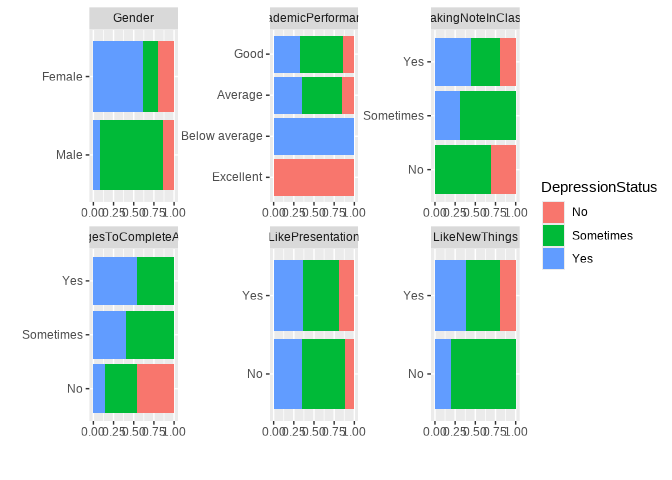

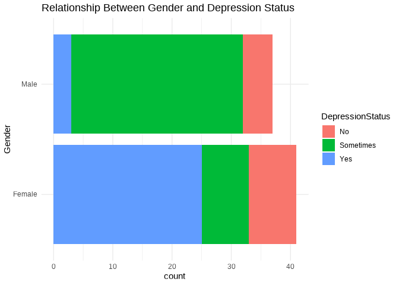

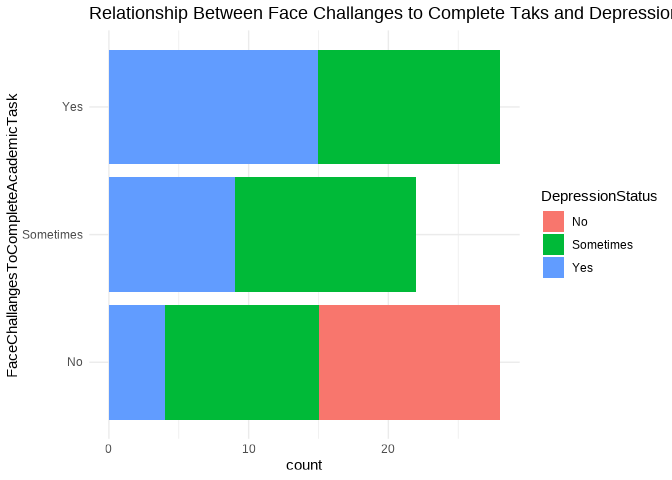

Statistical tests between Depression Status, Gender and Challenge to Complete Tasks

Chi-Squared Test for Gender and Depression Status

| X Squared | P-Value | Degrees of Freedom | Method |
| --- | --- | --- | --- |
| 16.17949 | 0.002787537 | 4 | Chi-squared test for given probabilities |

Effect sizes were labelled following Funder’s (2019) recommendations.

The Chi-squared test for given probabilities / goodness of fit of gender_depression to a uniform distribution suggests that the effect is statistically significant, and small (chi2 = 16.18, p = 0.003; Fei = 0.16, 95% CI [0.07, 1.00])

Chi-Squared Test for Challange to Complete Tasks and Depression Status

| X Squared | P-Value | Degrees of Freedom | Method |
| --- | --- | --- | --- |
| 3.576923 | 0.1672172 | 2 | Chi-squared test for given probabilities |

Effect sizes were labelled following Funder’s (2019) recommendations.

The Chi-squared test for given probabilities / goodness of fit of challange_depression to a uniform distribution suggests that the effect is statistically not significant, and small (chi2 = 3.58, p = 0.167; Fei = 0.11, 95% CI [0.00, 1.00])

# Contact

Email: lindolfoj47.lj@gmail.com

Linkedin: www.linkedin.com/in/ lindolfo-cavalcanti

GitHub: https://github.com/Lindolfo-Cavalcanti

# References

- Cui B (2024). *DataExplorer: Automate Data Exploration and Treatment*. R package version 0.8.3, https://CRAN.R-project.org/package=DataExplorer.
- Dayanand Ubrangala, R K, Prasad Kondapalli R, Putatunda S (2024). *SmartEDA: Summarize and Explore the Data*. R package version 0.3.10, https://CRAN.R-project.org/package=SmartEDA.
- Gohel D, Skintzos P (2024). *flextable: Functions for Tabular Reporting*. R package version 0.9.6, https://CRAN.R-project.org/package=flextable.
- Grolemund G, Wickham H (2011). “Dates and Times Made Easy with lubridate.” *Journal of Statistical Software*, *40*(3), 1-25. https://www.jstatsoft.org/v40/i03/.
- Makowski D, Lüdecke D, Patil I, Thériault R, Ben-Shachar M, Wiernik B (2023). “Automated Results Reporting as a Practical Tool to Improve Reproducibility and Methodological Best Practices Adoption.” *CRAN*. https://easystats.github.io/report/.
- Mayer M (2024). *missRanger: Fast Imputation of Missing Values*. R package version 2.5.0, https://CRAN.R-project.org/package=missRanger.
- Müller K, Wickham H (2023). *tibble: Simple Data Frames*. R package version 3.2.1, https://CRAN.R-project.org/package=tibble.
- R Core Team (2024). *R: A Language and Environment for Statistical Computing*. R Foundation for Statistical Computing, Vienna, Austria. https://www.R-project.org/.
- Ryu C (2024). *dlookr: Tools for Data Diagnosis, Exploration, Transformation*. R package version 0.6.3, https://CRAN.R-project.org/package=dlookr.
- Wickham H (2016). *ggplot2: Elegant Graphics for Data Analysis*. Springer-Verlag New York. ISBN 978-3-319-24277-4, https://ggplot2.tidyverse.org.
- Wickham H (2023). *forcats: Tools for Working with Categorical Variables (Factors)*. R package version 1.0.0, https://CRAN.R-project.org/package=forcats.
- Wickham H (2023). *stringr: Simple, Consistent Wrappers for Common String Operations*. R package version 1.5.1, https://CRAN.R-project.org/package=stringr.
- Wickham H, Averick M, Bryan J, Chang W, McGowan LD, François R, Grolemund G, Hayes A, Henry L, Hester J, Kuhn M, Pedersen TL, Miller E, Bache SM, Müller K, Ooms J, Robinson D, Seidel DP, Spinu V, Takahashi K, Vaughan D, Wilke C, Woo K, Yutani H (2019). “Welcome to the tidyverse.” *Journal of Open Source Software*, *4*(43), 1686. doi:10.21105/joss.01686 https://doi.org/10.21105/joss.01686.
- Wickham H, François R, Henry L, Müller K, Vaughan D (2023). *dplyr: A Grammar of Data Manipulation*. R package version 1.1.4, https://CRAN.R-project.org/package=dplyr.
- Wickham H, Henry L (2023). *purrr: Functional Programming Tools*. R package version 1.0.2, https://CRAN.R-project.org/package=purrr.
- Wickham H, Hester J, Bryan J (2024). *readr: Read Rectangular Text Data*. R package version 2.1.5, https://CRAN.R-project.org/package=readr.
- Wickham H, Vaughan D, Girlich M (2024). *tidyr: Tidy Messy Data*. R package version 1.3.1, https://CRAN.R-project.org/package=tidyr.

Analyses were conducted using the R Statistical language (version 4.4.1; R Core Team, 2024), using the packages DataExplorer (version 0.8.3; Cui B, 2024), SmartEDA (version 0.3.10; Dayanand Ubrangala et al., 2024), flextable (version 0.9.6; Gohel D, Skintzos P, 2024), lubridate (version 1.9.3; Grolemund G, Wickham H, 2011), report (version 0.5.9; Makowski D et al., 2023), missRanger (version 2.5.0; Mayer M, 2024), tibble (version 3.2.1; Müller K, Wickham H, 2023), dlookr (version 0.6.3; Ryu C, 2024), ggplot2 (version 3.5.1; Wickham H, 2016), forcats (version 1.0.0; Wickham H, 2023), stringr (version 1.5.1; Wickham H, 2023), tidyverse (version 2.0.0; Wickham H et al., 2019), dplyr (version 1.1.4; Wickham H et al., 2023), purrr (version 1.0.2; Wickham H, Henry L, 2023), readr (version 2.1.5; Wickham H et al., 2024) and tidyr (version 1.3.1; Wickham H et al., 2024).